## Reading data

**Vector data** - use `sf` package and `st_read()` function

**Raster data** - use the raster package and `raster()` or `brick()` function

`raster()` function is for reading single band rasters `brick()` function is for reading multi-band rasters

## Writing data

**Vector data** - use st_write(m_poly, “path/to/file.ext”)

**Raster data** - writeRaster(my_raster, “path/to/raster.ext”)

```r
# load sf package
library(sf)
# read in the trees shapefile
trees <- st_read("data/trees/trees.shp")
# read in neighborhoods
neighborhoods <- st_read("data/neighborhoods/neighborhoods.shp")
# read in parks
parks <- st_read("data/parks/parks.shp")
# view the first few trees
head(trees)
```

```
## Simple feature collection with 6 features and 7 fields
## Geometry type: POINT
## Dimension:     XY
## Bounding box:  xmin: -74.13116 ymin: 40.62351 xmax: -73.80057 ymax: 40.77393
## Geodetic CRS:  WGS 84
##   tree_id  nta longitude latitude stump_diam      species      boroname
## 1  558423 QN76 -73.80057 40.67035          0  honeylocust        Queens
## 2  286191 MN32 -73.95422 40.77393          0 Callery pear     Manhattan
## 3  257044 QN70 -73.92309 40.76196          0  Chinese elm        Queens
## 4  603262 BK09 -73.99866 40.69312          0       cherry      Brooklyn
## 5   41769 SI22 -74.11773 40.63166          0       cherry Staten Island
## 6   24024 SI07 -74.13116 40.62351          0    red maple Staten Island
##                     geometry
## 1 POINT (-73.80057 40.67035)
## 2 POINT (-73.95422 40.77393)
## 3 POINT (-73.92309 40.76196)
## 4 POINT (-73.99866 40.69312)
## 5 POINT (-74.11773 40.63166)
## 6 POINT (-74.13116 40.62351)
```

### Reading Raster data

```r
# load library raster
library(raster)
```

```r
# read in tree camopy single-band raster
canopy <- raster("data/canopy.tif")

# Read in manhattan Landsat image multi-band raster
manhattan <- brick("data/manhattan.tif")

# ge the class for the new objects
class(canopy)
```

```
## [1] "RasterLayer"
## attr(,"package")
## [1] "raster"
```

```r
class(manhattan)
```

```
## [1] "RasterBrick"
## attr(,"package")
## [1] "raster"
```

#### sf objects and data frames

sf are just data frames with some special properties. this means that packages like `dplyr` can be used to manipulate sf objects

```r
library(dplyr)
# use filter to limit honey locust trees
honeylocust <- trees %>% filter(species == "honeylocust")

# count the number of rows
nrow(honeylocust)
```

```
## [1] 6418
```

```r
# limit to tree_id and boroname variables

honeylocust_lim <- honeylocust %>% select(tree_id, boroname)
head(honeylocust_lim)
```

```
## Simple feature collection with 6 features and 2 fields
## Geometry type: POINT
## Dimension:     XY
## Bounding box:  xmin: -73.97524 ymin: 40.67035 xmax: -73.80057 ymax: 40.83136
## Geodetic CRS:  WGS 84
##   tree_id boroname                   geometry
## 1  558423   Queens POINT (-73.80057 40.67035)
## 2  548625 Brooklyn POINT (-73.97524 40.68575)
## 3  549439 Brooklyn POINT (-73.94137 40.67557)
## 4  181757 Brooklyn POINT (-73.89377 40.67169)
## 5  379387   Queens  POINT (-73.8221 40.69365)
## 6  383562    Bronx POINT (-73.90041 40.83136)
```

### Geometry as list-columns in sf

A list-column behaves to a certain extent like any other R column. the main difference is that instead of a standard value such as a single number, character or boolean value, each observation value in that column is a piece of an R list and that list can be as complex as needed. The list-column allows you to store farmore information in a single variable. so sf takes this advantage to store all geographic information for each feature in the list.

```r
library(tibble)
# create a sampledataframe with one column
df <- data.frame(a=1:3)

df
```

```
##   a
## 1 1
## 2 2
## 3 3
```

```r
# add a list column to the data frame
df$b <- list(1:4, 1:5, 1:10)

df
```

```
##   a                             b
## 1 1                    1, 2, 3, 4
## 2 2                 1, 2, 3, 4, 5
## 3 3 1, 2, 3, 4, 5, 6, 7, 8, 9, 10
```

```r
# convert dataframe to a tibble
as_tibble(df)
```

```
## # A tibble: 3 × 2
##       a b
##   <int> <list>
## 1     1 <int [4]>
## 2     2 <int [5]>
## 3     3 <int [10]>
```

```r
# pull out the third observation from both columns
df$a[3]
```

```
## [1] 3
```

```r
df$b[3]
```

```
## [[1]]
##  [1]  1  2  3  4  5  6  7  8  9 10
```

## Extracting geometric information from vector layers

```r
# if not loaded, read in parks shapefile

# compute areas of the parks

# incase of an error, turn off spherical geometry
sf_use_s2(FALSE)
```

```
## Spherical geometry (s2) switched off
```

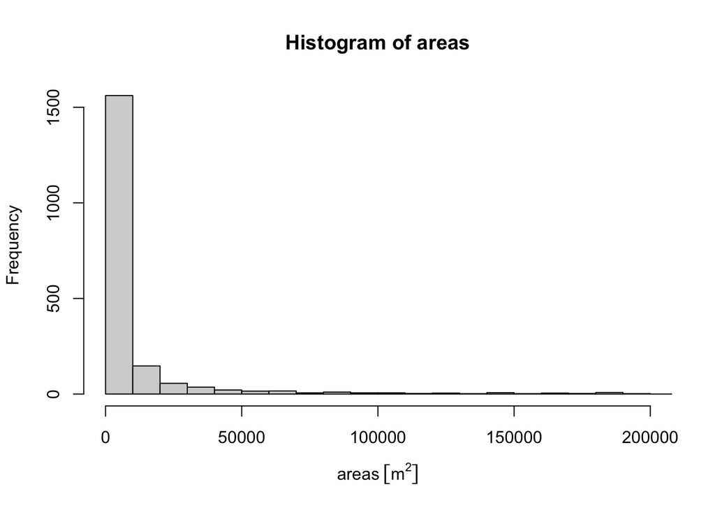

```r
areas <- st_area(parks)

# cerate a quick histogram of the areas usin g hist
hist(areas, xlim = c(0, 200000), breaks=1000)
```

```r
# filter the parcks greater than 3000(square meters)
head(parks)
```

```
## Simple feature collection with 6 features and 14 fields
## Geometry type: MULTIPOLYGON
## Dimension:     XY
## Bounding box:  xmin: -74.00659 ymin: 40.57779 xmax: -73.78185 ymax: 40.84531
## Geodetic CRS:  WGS 84
##                                                                           location
## 1 Queensboro Bridge, 41 Rd., 40 Ave. bet. The East River, Vernon Blvd., and 21 St.
## 2                                   City Island Ave bet. Centre St. and Winter St.
## 3                                                  Beach 116 St.,  Ocean Promenade
## 4                                       E 180 St bet. the Bronx River and Devoe Av
## 5                                            Vernon Blvd. bet. Broadway and 30 Dr.
## 6                                Bay View Ave. between Sea Gate Ave. and W. 33 St.
##   communityb nys_senate                 signname zipcode us_congres gispropnum
## 1   401, 402         12        Queensbridge Park   11101         12       Q104
## 2        210         34          Ambrosini Field   10464         14       X253
```

[output cut: 18 more lines]

Note that the result of functions like `st_area()` and `st_length()` will not be a traditional vector. Instead, the result has a class of units. which means the vector result is accompanied by metadata describing the object’s units.

So you need to remove the units with `unclass()`

or convert the val’s class to units

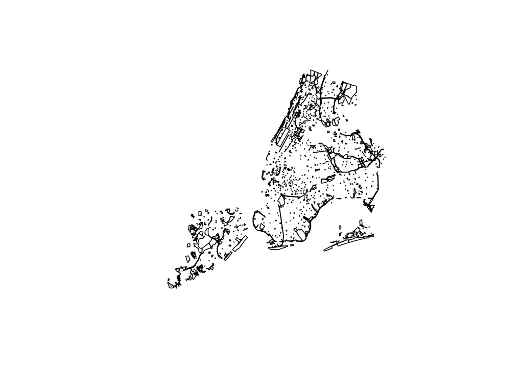

```r
# filter to parks greater than 3000 (square meters)
big_parks <- parks %>% filter(unclass(areas) > 3000)
plot(st_geometry(big_parks))
```